# How wrong may a useful model be?

Fundamental Techniques in Data Science with R

## Today

## This lecture

- model fit
- model complexity
- cross validation

## We use the following packages

```r
library(MASS)
library(dplyr)
library(magrittr)
library(ggplot2)
library(mice)
library(DAAG)
library(car)

set.seed(123)
```

## Model fit

## A simple model

```r
boys.fit <-
  na.omit(boys) %$% # Extremely wasteful
  lm(age ~ reg)
boys.fit
```

```
##
## Call:
## lm(formula = age ~ reg)
##
## Coefficients:
## (Intercept)      regeast      regwest     regsouth      regcity
##     14.7109      -0.8168      -0.7044      -0.6913      -0.6663
```

```r
boys %>% na.omit(boys) %$% aggregate(age, list(reg), mean)
```

```
##   Group.1        x
## 1   north 14.71094
## 2    east 13.89410
## 3    west 14.00657
## 4   south 14.01965
## 5    city 14.04460
```

## Plotting the model

```r
means <- boys %>% na.omit(boys) %>% group_by(reg) %>% summarise(age = mean(age))
```

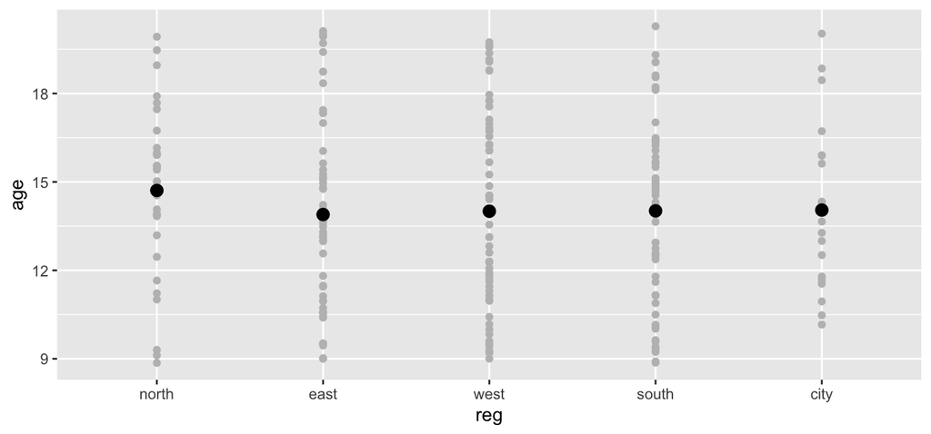

```r
ggplot(na.omit(boys), aes(x = reg, y = age)) +
  geom_point(color = "grey") +
  geom_point(data = means, stat = "identity", size = 3)
```

## Model parameters

```r
boys.fit %>%
  summary()
```

```
##
## Call:
## lm(formula = age ~ reg)
##
## Residuals:
##     Min      1Q  Median      3Q     Max
## -5.8519 -2.5301  0.0254  2.2274  6.2614
##
## Coefficients:
##             Estimate Std. Error t value Pr(>|t|)
## (Intercept)  14.7109     0.5660  25.993   <2e-16 ***
## regeast      -0.8168     0.7150  -1.142    0.255
## regwest      -0.7044     0.6970  -1.011    0.313
## regsouth     -0.6913     0.6970  -0.992    0.322
## regcity      -0.6663     0.9038  -0.737    0.462
## ---
## Signif. codes:  0 '***' 0.001 '**' 0.01 '*' 0.05 '.' 0.1 ' ' 1
##
## Residual standard error: 3.151 on 218 degrees of freedom
## Multiple R-squared:  0.006745,   Adjusted R-squared:  -0.01148
## F-statistic: 0.3701 on 4 and 218 DF,  p-value: 0.8298
```

## Is it a good model?

```r
boys.fit %>%
  anova()
```

```
## Analysis of Variance Table
##
## Response: age
##            Df Sum Sq Mean Sq F value Pr(>F)
## reg         4   14.7  3.6747  0.3701 0.8298
## Residuals 218 2164.6  9.9293
```

It is not a very informative model. The `anova` is not significant, indicating that the contribution of the residuals is larger than the contribution of the model.

The outcome `age` does not change significantly when `reg` is varied.

## Model factors

```r
boys.fit %>%
  model.matrix() %>%
  head(n = 10)
```

```
##    (Intercept) regeast regwest regsouth regcity
## 1            1       0       0        0       0
## 2            1       0       0        1       0
## 3            1       0       0        1       0
## 4            1       1       0        0       0
## 5            1       0       1        0       0
## 6            1       1       0        0       0
## 7            1       0       0        0       0
## 8            1       0       1        0       0
## 9            1       0       0        1       0
## 10           1       0       1        0       0
```

`R` expands the categorical variable for us

- it dummy-codes the `5` categories into `4` dummies (and an intercept).

## Post hoc comparisons

```r
coef <- boys.fit %>% aov() %>% summary.lm()
coef
```

```
##
## Call:
## aov(formula = .)
##
## Residuals:
##     Min      1Q  Median      3Q     Max
## -5.8519 -2.5301  0.0254  2.2274  6.2614
##
## Coefficients:
##             Estimate Std. Error t value Pr(>|t|)
## (Intercept)  14.7109     0.5660  25.993   <2e-16 ***
## regeast      -0.8168     0.7150  -1.142    0.255
## regwest      -0.7044     0.6970  -1.011    0.313
## regsouth     -0.6913     0.6970  -0.992    0.322
## regcity      -0.6663     0.9038  -0.737    0.462
## ---
## Signif. codes:  0 '***' 0.001 '**' 0.01 '*' 0.05 '.' 0.1 ' ' 1
##
## Residual standard error: 3.151 on 218 degrees of freedom
## Multiple R-squared:  0.006745,   Adjusted R-squared:  -0.01148
## F-statistic: 0.3701 on 4 and 218 DF,  p-value: 0.8298
```

## Post hoc comparisons

Without adjustments for the p-value

```r
na.omit(boys) %$% pairwise.t.test(age, reg, p.adj = "none")
```

```
##
##  Pairwise comparisons using t tests with pooled SD
##
## data:  age and reg
##
##       north east west south
## east  0.25  -    -    -
## west  0.31  0.85 -    -
## south 0.32  0.83 0.98 -
## city  0.46  0.86 0.96 0.98
##
## P value adjustment method: none
```

## Post hoc comparisons

With adjusted p-values cf. Bonferoni correction

```r
na.omit(boys) %$% pairwise.t.test(age, reg, p.adj = "bonf")
```

```
##
##  Pairwise comparisons using t tests with pooled SD
##
## data:  age and reg
##
##       north east west south
## east  1     -    -    -
## west  1     1    -    -
## south 1     1    1    -
## city  1     1    1    1
##
## P value adjustment method: bonferroni
```

## Post hoc comparisons

Manually calculated

```r
p.val <- coef$coefficients
p.adjust(p.val[, "Pr(>|t|)"], method = "bonferroni")
```

```
##  (Intercept)      regeast      regwest     regsouth      regcity
## 5.077098e-68 1.000000e+00 1.000000e+00 1.000000e+00 1.000000e+00
```

If you have trouble reading scientific notation, `5.077098e-68` means the following

This indicates that the comma should be moved 68 places to the left:

\[5.077098\text{e-68} = .000000000000000000000000000000000000\] \[000000000000000000000000000000005077098\]

## AIC

Akaike’s *An Information Criterion*

```r
boys.fit %>%
  AIC()
```

```
## [1] 1151.684
```

### What is AIC

AIC comes from information theory and can be used for model selection. The AIC quantifies the information that is lost by the statistical model, through the assumption that the data come from the same model. In other words: AIC measures the fit of the model to the data.

- The better the fit, the less the loss in information
- AIC works on the log scale:
  - \(\text{log}(0) = -\infty\), \(\text{log}(1) = 0\), etc.
- the closer the AIC is to \(-\infty\), the better

## Model comparison

## A new model

Let’s add predictor `hgt` to the model:

```r
boys.fit2 <-
  na.omit(boys) %$%
  lm(age ~ reg + hgt)

boys.fit %>% AIC()
```

```
## [1] 1151.684
```

```r
boys.fit2 %>% AIC()
```

```
## [1] 836.3545
```

## Another model

Let’s add `wgt` to the model

```r
boys.fit3 <-
  na.omit(boys) %$%
  lm(age ~ reg + hgt + wgt)
```

## And another model

Let’s add `wgt` and the interaction between `wgt` and `hgt` to the model

```r
boys.fit4 <-
  na.omit(boys) %$%
  lm(age ~ reg + hgt * wgt)
```

is equivalent to

```r
boys.fit4 <-
  na.omit(boys) %$%
  lm(age ~ reg + hgt + wgt + hgt:wgt)
```

## Model comparison

```r
boys.fit %>% AIC()
```

```
## [1] 1151.684
```

```r
boys.fit2 %>% AIC()
```

```
## [1] 836.3545
```

```r
boys.fit3 %>% AIC()
```

```
## [1] 822.4164
```

```r
boys.fit4 %>% AIC()
```

```
## [1] 823.0386
```

## Another form of model comparison

```r
anova(boys.fit, boys.fit2, boys.fit3, boys.fit4)
```

```
## Analysis of Variance Table
##
## Model 1: age ~ reg
## Model 2: age ~ reg + hgt
## Model 3: age ~ reg + hgt + wgt
## Model 4: age ~ reg + hgt * wgt
##   Res.Df     RSS Df Sum of Sq        F    Pr(>F)
## 1    218 2164.59
## 2    217  521.64  1   1642.94 731.8311 < 2.2e-16 ***
## 3    216  485.66  1     35.98  16.0276 8.595e-05 ***
## 4    215  482.67  1      2.99   1.3324    0.2497
## ---
## Signif. codes:  0 '***' 0.001 '**' 0.01 '*' 0.05 '.' 0.1 ' ' 1
```

## Inspect `boys.fit3`

```r
boys.fit3 %>% anova()
```

```
## Analysis of Variance Table
##
## Response: age
##            Df  Sum Sq Mean Sq  F value    Pr(>F)
## reg         4   14.70    3.67   1.6343    0.1667
## hgt         1 1642.94 1642.94 730.7065 < 2.2e-16 ***
## wgt         1   35.98   35.98  16.0029 8.688e-05 ***
## Residuals 216  485.66    2.25
## ---
## Signif. codes:  0 '***' 0.001 '**' 0.01 '*' 0.05 '.' 0.1 ' ' 1
```

## Inspect `boys.fit4`

```r
boys.fit4 %>% anova()
```

```
## Analysis of Variance Table
##
## Response: age
##            Df  Sum Sq Mean Sq  F value    Pr(>F)
## reg         4   14.70    3.67   1.6368    0.1661
## hgt         1 1642.94 1642.94 731.8311 < 2.2e-16 ***
## wgt         1   35.98   35.98  16.0276 8.595e-05 ***
## hgt:wgt     1    2.99    2.99   1.3324    0.2497
## Residuals 215  482.67    2.24
## ---
## Signif. codes:  0 '***' 0.001 '**' 0.01 '*' 0.05 '.' 0.1 ' ' 1
```

It seems that `reg` and the interaction `hgt:wgt` are redundant

## Remove `reg`

```r
boys.fit5 <-
  na.omit(boys) %$%
  lm(age ~ hgt + wgt)
```

Let’s revisit the comparison

```r
anova(boys.fit, boys.fit2, boys.fit3, boys.fit5)
```

```
## Analysis of Variance Table
##
## Model 1: age ~ reg
## Model 2: age ~ reg + hgt
## Model 3: age ~ reg + hgt + wgt
## Model 4: age ~ hgt + wgt
##   Res.Df     RSS Df Sum of Sq        F    Pr(>F)
## 1    218 2164.59
## 2    217  521.64  1   1642.94 730.7065 < 2.2e-16 ***
## 3    216  485.66  1     35.98  16.0029 8.688e-05 ***
## 4    220  492.43 -4     -6.77   0.7529    0.5571
## ---
## Signif. codes:  0 '***' 0.001 '**' 0.01 '*' 0.05 '.' 0.1 ' ' 1
```

But the `boys.fit5` model is better than the previous model with fewer parameters

## Stepwise regression

We start with the full model, which contains all parameters for all columns.

The most straightforward way to go about this is by specifying the following model:

```r
full.model <- lm(age ~ ., data = na.omit(boys))
full.model
```

```
##
## Call:
## lm(formula = age ~ ., data = na.omit(boys))
##
## Coefficients:
## (Intercept)          hgt          wgt          bmi           hc        gen.L
##    2.556051     0.059987    -0.009846     0.142162    -0.024086     1.287455
##       gen.Q        gen.C        gen^4        phb.L        phb.Q        phb.C
##   -0.006861    -0.187256     0.034186     1.552398     0.499620     0.656277
##       phb^4        phb^5           tv      regeast      regwest     regsouth
##   -0.094722    -0.113686     0.074321    -0.222249    -0.233307    -0.258771
##     regcity
##    0.188423
```

## Stepwise regression - continued

We can then start with specifying the stepwise model. In this case we choose direction `both`.

```r
step.model <- step(full.model, direction = "both",
                      trace = FALSE)
step.model
```

```
##
## Call:
## lm(formula = age ~ hgt + bmi + phb + tv, data = na.omit(boys))
##
## Coefficients:
## (Intercept)          hgt          bmi        phb.L        phb.Q        phb.C
##     2.07085      0.05482      0.10742      2.70328      0.28877      0.48492
##       phb^4        phb^5           tv
##    -0.06225     -0.15167      0.07957
```

Other options are

- `forward`: fit all univariate models, add the best predictor and continue.
- `backward`: fit the full model, eliminate the worst predictor and continue.

## Summary

```r
step.model %>% summary
```

```
##
## Call:
## lm(formula = age ~ hgt + bmi + phb + tv, data = na.omit(boys))
##
## Residuals:
##     Min      1Q  Median      3Q     Max
## -3.5077 -0.7144 -0.0814  0.6850  3.1724
##
## Coefficients:
##              Estimate Std. Error t value Pr(>|t|)
## (Intercept)  2.070854   1.576365   1.314  0.19036
## hgt          0.054822   0.009986   5.490 1.13e-07 ***
## bmi          0.107415   0.030135   3.564  0.00045 ***
## phb.L        2.703275   0.437108   6.184 3.12e-09 ***
## phb.Q        0.288768   0.211836   1.363  0.17426
## phb.C        0.484921   0.202856   2.390  0.01769 *
## phb^4       -0.062246   0.208472  -0.299  0.76555
## phb^5       -0.151667   0.240599  -0.630  0.52912
## tv           0.079573   0.019600   4.060 6.89e-05 ***
## ---
## Signif. codes:  0 '***' 0.001 '**' 0.01 '*' 0.05 '.' 0.1 ' ' 1
##
## Residual standard error: 1.172 on 214 degrees of freedom
## Multiple R-squared:  0.8651, Adjusted R-squared:   0.86
## F-statistic: 171.5 on 8 and 214 DF,  p-value: < 2.2e-16
```

## Stepwise regression - AIC

```r
full.model <- lm(age ~ ., data = na.omit(boys))
step.model <- MASS::stepAIC(full.model, direction = "both",
                      trace = FALSE)
step.model
```

```
##
## Call:
## lm(formula = age ~ hgt + bmi + phb + tv, data = na.omit(boys))
##
## Coefficients:
## (Intercept)          hgt          bmi        phb.L        phb.Q        phb.C
##     2.07085      0.05482      0.10742      2.70328      0.28877      0.48492
##       phb^4        phb^5           tv
##    -0.06225     -0.15167      0.07957
```

## Influence of cases

DfBeta calculates the change in coefficients depicted as deviation in SE’s.

```r
step.model %>%
  dfbeta() %>%
  head(n = 7)
```

```
##       (Intercept)           hgt           bmi        phb.L         phb.Q
## 3279 -0.142127090  0.0010828575 -0.0021654085 -0.021523825 -0.0006087783
## 3283 -0.005201914  0.0001127452 -0.0014100750  0.009068652 -0.0147293625
## 3296 -0.081439010  0.0004244061  0.0002603379 -0.009247562 -0.0071293767
## 3321 -0.084630826  0.0004186923  0.0008222594 -0.005498486 -0.0059276580
## 3323  0.154386486 -0.0004476521 -0.0052964367  0.042872835 -0.0213761347
## 3327 -0.046095468  0.0001081361  0.0011150546 -0.004047875 -0.0085461280
## 3357 -0.045933397  0.0001345605  0.0009770371 -0.005087053 -0.0062604484
##            phb.C        phb^4        phb^5            tv
## 3279 0.007427067 -0.004226982 -0.001213833  0.0001061106
## 3283 0.011761595 -0.005498411  0.001164307  0.0007051901
## 3296 0.008538302 -0.003688611  0.000842872  0.0002494383
## 3321 0.006839217 -0.003341741  0.000866896 -0.0002569914
## 3323 0.011758694 -0.006659755  0.000493897  0.0012317886
## 3327 0.007807966 -0.002901270  0.001499505  0.0003376220
## 3357 0.006152384 -0.002274777  0.001148552  0.0002329346
```

## Prediction

## Fitted values

Let’s use the simpler `anscombe` data example

```r
fit <- anscombe %$% lm(y1 ~ x1)

y_hat <-
  fit %>%
  fitted.values()
```

The residual is then calculated as

```r
y_hat - anscombe$y1
```

```
##           1           2           3           4           5           6
## -0.03900000  0.05081818  1.92127273 -1.30909091  0.17109091  0.04136364
##           7           8           9          10          11
## -1.23936364  0.74045455 -1.83881818  1.68072727 -0.17945455
```

## Predict new values

If we introduce new values for the predictor `x1`, we can generate predicted values from the model

```r
new.x1 <- data.frame(x1 = 1:20)
fit %>% predict(newdata = new.x1)
```

```
##         1         2         3         4         5         6         7         8
##  3.500182  4.000273  4.500364  5.000455  5.500545  6.000636  6.500727  7.000818
##         9        10        11        12        13        14        15        16
##  7.500909  8.001000  8.501091  9.001182  9.501273 10.001364 10.501455 11.001545
##        17        18        19        20
## 11.501636 12.001727 12.501818 13.001909
```

## Predictions are draws from the regression line

```r
pred <- fit %>% predict(newdata = new.x1)
lm(pred ~ new.x1$x1)$coefficients
```

```
## (Intercept)   new.x1$x1
##   3.0000909   0.5000909
```

```r
fit$coefficients
```

```
## (Intercept)          x1
##   3.0000909   0.5000909
```

## Prediction intervals

```r
fit %>% predict(interval = "prediction")
```

```
##          fit      lwr       upr
## 1   8.001000 5.067072 10.934928
## 2   7.000818 4.066890  9.934747
## 3   9.501273 6.390801 12.611745
## 4   7.500909 4.579129 10.422689
## 5   8.501091 5.531014 11.471168
## 6  10.001364 6.789620 13.213107
## 7   6.000636 2.971271  9.030002
## 8   5.000455 1.788711  8.212198
## 9   9.001182 5.971816 12.030547
## 10  6.500727 3.530650  9.470804
## 11  5.500545 2.390073  8.611017
```

A prediction interval reflects the uncertainty around a single value. The confidence interval reflects the uncertainty around the mean prediction values.

## Assessing predictive accuracy

## K-fold cross-validation

- Divide sample in \(k\) mutually exclusive training sets
- Do for all \(j\in\{1,\dots,k\}\) training sets
  1. fit model to training set \(j\)
  2. obtain predictions for test set \(j\) (remaining cases)
  3. compute residual variance (MSE) for test set \(j\)
- Compare MSE in cross-validation with MSE in sample
- Small difference suggests good predictive accuracy

## The original model

```r
fit %>% summary()
```

```
##
## Call:
## lm(formula = y1 ~ x1)
##
## Residuals:
##      Min       1Q   Median       3Q      Max
## -1.92127 -0.45577 -0.04136  0.70941  1.83882
##
## Coefficients:
##             Estimate Std. Error t value Pr(>|t|)
## (Intercept)   3.0001     1.1247   2.667  0.02573 *
## x1            0.5001     0.1179   4.241  0.00217 **
## ---
## Signif. codes:  0 '***' 0.001 '**' 0.01 '*' 0.05 '.' 0.1 ' ' 1
##
## Residual standard error: 1.237 on 9 degrees of freedom
## Multiple R-squared:  0.6665, Adjusted R-squared:  0.6295
## F-statistic: 17.99 on 1 and 9 DF,  p-value: 0.00217
```

## K-fold cross-validation `anscombe` data

```r
DAAG::CVlm(anscombe, fit, plotit=F, printit=T)
```

[output not shown]

## K-fold cross-validation `anscombe` data

- residual variance sample is \(1.24^2 \approx 1.53\)
- residual variance cross-validation is 2.04
- regression lines in the 3 folds are not the same, but similar

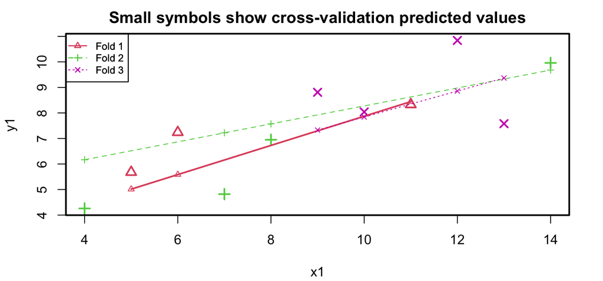

```r
DAAG::CVlm(anscombe, fit, plotit="Observed", printit=F)
```

## Plotting the residuals

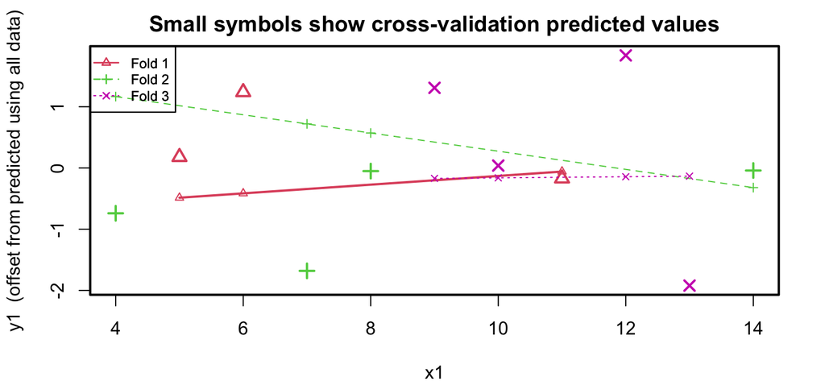

```r
DAAG::CVlm(anscombe, fit, plotit="Residual", printit=F)
```

## K-fold cross-validation `boys` data

- residual variance sample is 1.37
- residual variance cross-validation is 1.46
- regression lines in the 3 folds almost identical

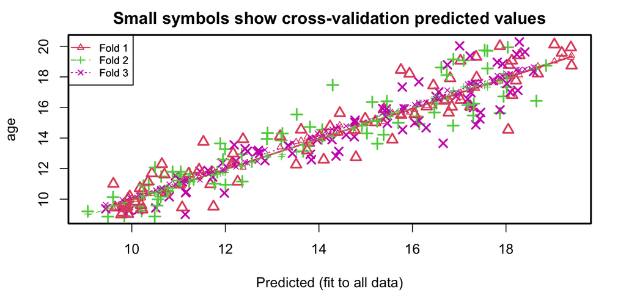

```r
DAAG::CVlm(na.omit(boys), step.model, plotit="Observed", printit=F)
```

## Plotting the residuals

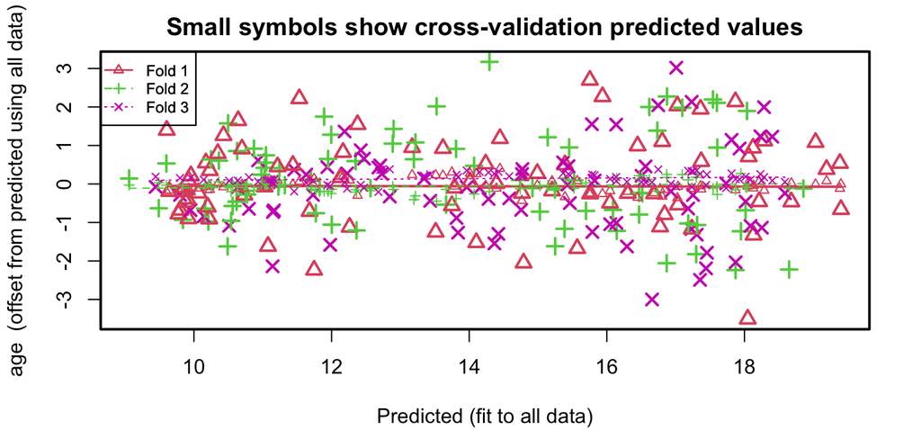

```r
DAAG::CVlm(na.omit(boys), step.model, plotit="Residual", printit=F)
```

## How many cases are used?

```r
na.omit(boys) %$%
  lm(age ~ reg + hgt * wgt) %>%
  nobs()
```

```
## [1] 223
```

If we would not have used `na.omit()`

```r
boys %$%
  lm(age ~ reg + hgt * wgt) %>%
  nobs()
```

```
## [1] 724
```

## Next week:

- Logistic regression